# Questionnaire Report for Canary rockfish

# Management Characteristics

## Types of fishery management that are possible

| Answered |
| --- |
| TAC (Total Allowable Catch): a catch limit |
| TAE (Total Allowable Effort): an effort limit |
| Size limit |
| Time-area closures (a marine reserve) |

Justification

1. Describe what, if any, current management measures are used to constrain catch/effort.  
“The current overall TAC is 1193 t (Table 2) with 87.70% of the canary rockfish quota allocated to trawl (T license), 11.77% to outer coast HL rockfish harvesters (ZN-outside license), and 0.53% to Pacific halibut harvesters (L license). Catches in the trawl fleet are constrained by an annual quota and vessel-specific quotas.  
Hook and line catches were constrained by annual quotas and trip limits. Since 2006, there has been virtually 100% monitoring in all remaining groundfish sectors, with the exception of a small trawl fishery in the Strait of Georgia. The HL harvesters are also now constrained by sector and vessel quotas. Groundfish catches in the recreational fishery are constrained by a bag limit (for “all rockfish” combined) which varies by area." (Stanley et al. 2009)  
2. Describe historical management measures, if any.  
“There is also a drop in exploitation rate in the mid-1990s which coincides with significant management changes which were implemented in the trawl fishery in the mid-1990s. Additional management changes have since been implemented in the hook and line fishery in the mid- 2000s, which should also lead to reductions in exploitation on this species.”; “(referring to the commercial trawl fishery) We argue that catch rate data prior to April 1996 are not comparable over time, owing largely to the significant and varying degrees of mis-reporting. As noted before, our concerns about this period are based on the reporting of a large number of landing events, known to the senior author and others, for which the fishing logs and sales slips were obviously falsified. Furthermore, the trip limits were varied over time; thus the directions of the biases would vary from one year to the next, or over groups of years. The dysfunction in the catch reporting system and the resulting inability to manage to quotas was the primary reason that the Department imposed 100% observer coverage on the trawl fishery in 1996.” (Stanley et al. 2009)  
3. Describe main strengths and weaknesses of current monitoring and enforcement capacity.  
At-sea observer coverage approaches 100%; dockside monitoring is 100%. I see no weaknesses with monitoring.  
4. Describe and reference any legal/policy requirements for management, monitoring and enforcement.

## TAC offset: consistent overages/underages

| Answered |
| --- |
| Large underages (40% - 70% of recommended) |
| Underages (70% - 90% of recommended) |
| Slight underages (90% - 100% of recommended) |
| Taken exactly (95% - 105% of recommended) |
| Slight overages (100% - 110% of recommended) |
| Overages (110% - 150% of recommended) |
| Large overages (150% - 200% of recommended) |

| Justification |
| --- |
| See table 2 (from Stanley et al. 2009) |

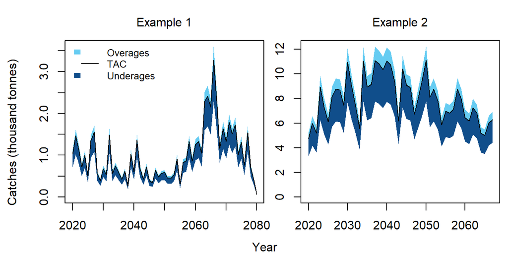

## TAC implementation variability

| Answered |
| --- |
| Constant (V < 1%) |
| Not variable (1% < V < 5%) |
| Low variability (5% < V < 10%) |
| Variable (10% < V < 20%) |
| Highly variable (20% < V < 40%) |

| Justification |
| --- |
| See Table 2 in Stanley et al. 2009 |

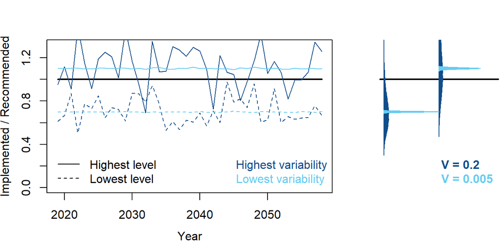